# Computer Science 1

7. Replace the histogram used in the previous point with a density plot and a box plot. Select `Analyses / Exploration / Descriptions` for the density plot and again for the boxplot.

[figure not shown]

Density plot for mileage (`city_mpg`)

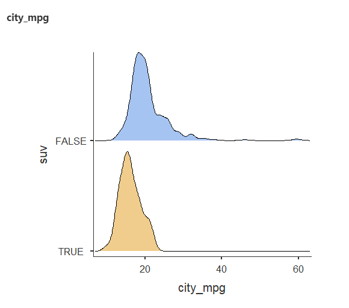

Density plot for mileage (`city_mpg`)

[figure not shown]

Boxplot for mileage (`city_mpg`)

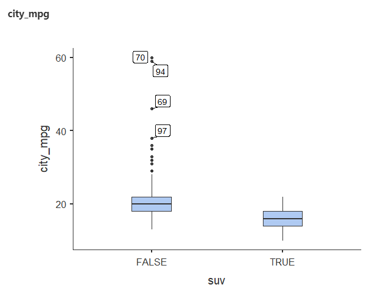

Boxplot for mileage (`city_mpg`)

8. The mileage of a car tends to be associated with the size of its engine (as measured by the number of cylinders). To explore the relationship between these two variables, you could stick to using histograms, but in this point you’ll try your hand at two alternatives: the box plot and the density plot. We have already looked at the number of cylinders (`ncyl`), now let’s see what values it has at all, and how many times it takes. To do this, let’s first convert it to an ordinal variable and write a frequency table on it.

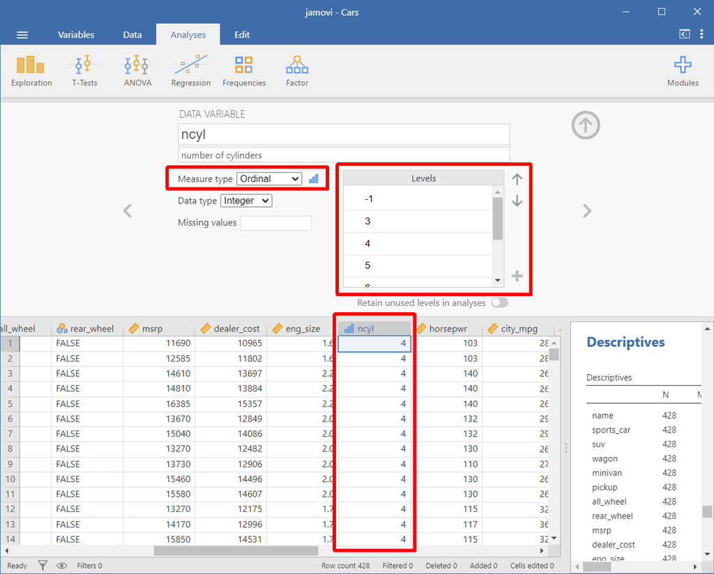

Convert `ncyl` to ordinal)

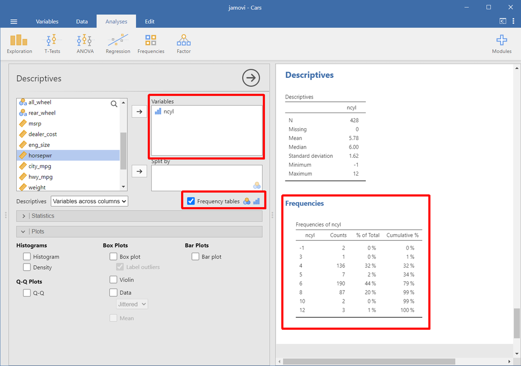

Frequency table for `ncyl`

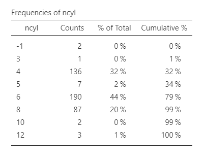

Frequency table for `ncyl`

A quick look at the frequency table shows that there are more possible levels of `ncyl` than you might think. Here, restrict your attention to the most common levels.

9. Transform a new variable `ncyl_468` from `ncyl` to get a new variable with only 4, 6, and 8 cylinders.

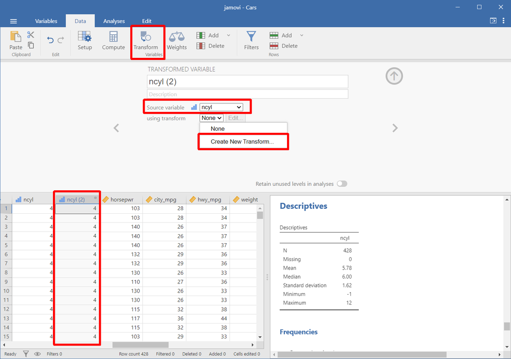

Transform a variable

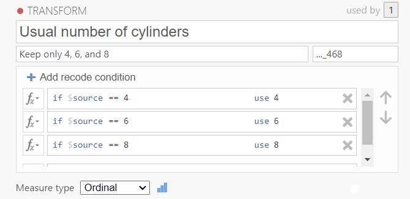

Transformation

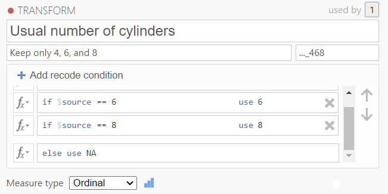

Transformation

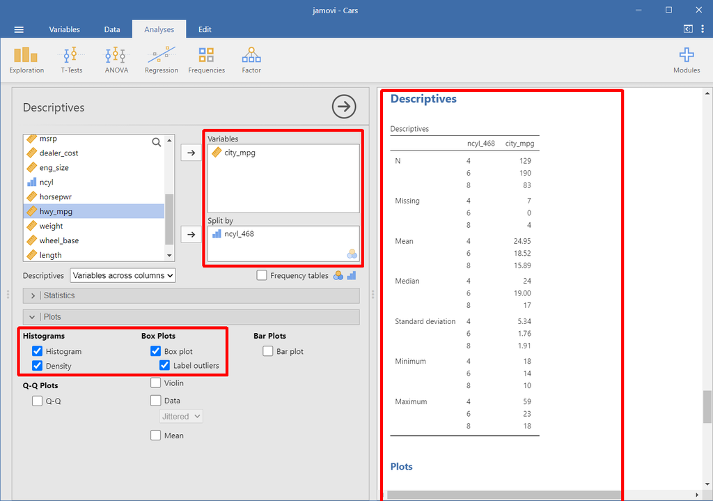

Graphical tools for numeric variable splity by common cylinders

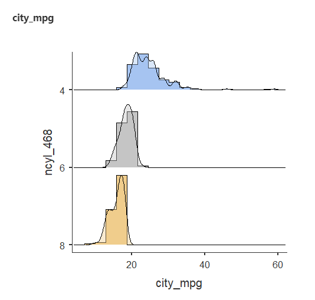

Histogram and density plot of `city_mpg` separated out by `ncyl_468`

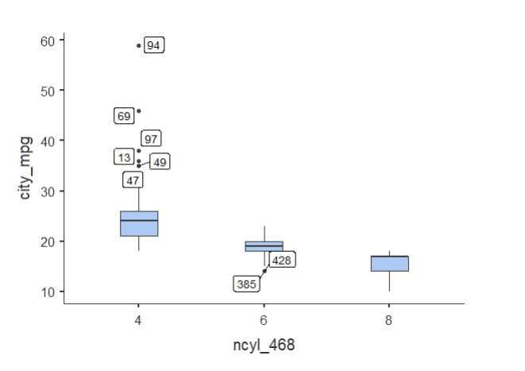

Side-by-side box plots of `city_mpg` separated out by `ncyl_468`

From the figures above we can say:

- The highest mileage cars have 4 cylinders.
- The typical 4 cylinder car gets better mileage than typical 6 cylinder car, which gets better mileage than the typical 8 cylinder car.
- Most of the 4 cylinder cars get better mileage than even the most efficient 8 cylinder cars.
- The variability in mileage of 8 cylinder cars is smaller then the variabilty in mileage of 4 cylinder cars.
10. Save and send the file `Cars.omv` to the `abari.kurzus@gmail.com`. The subject of this email is `Lab09 - Problem 3`.

**TipHistogram**

A histogram is a graphical representation used in descriptive statistics to visualize the distribution of a variable, particularly for numerical data. It provides a way to display the frequency or count of data points falling within specific intervals or “bins.” Histograms are useful for understanding the shape, central tendency, and spread of a dataset, as well as identifying patterns and outliers.

Key characteristics of a histogram include:

- Bins or Intervals: The range of the data is divided into intervals, or bins, along the horizontal axis (X-axis). Each bin represents a specific range of values.
- Frequency or Count: The vertical axis (Y-axis) displays the frequency or count of data points that fall into each bin. The height of each bar in the histogram represents how many data points are within the corresponding interval.
- Bar Width: The width of the bars in a histogram can vary depending on the choice of bin width. The choice of bin width can affect the appearance and interpretation of the histogram.
- Continuous Data: Histograms are typically used for continuous numerical data. For discrete data, a similar visualization called a bar chart may be used.
- Sum of Bar Heights: The sum of the heights of all bars in a histogram is equal to the total number of data points in the dataset.

Histograms help to reveal various characteristics of the data distribution:

- Shape: The shape of the histogram can provide insights into whether the data is normally distributed, skewed, bimodal (having two peaks), or exhibits other patterns.
- Central Tendency: The central tendency of the data can be identified by looking at the peak or mode of the histogram.
- Spread: The spread or variability of the data can be observed by examining the width and dispersion of the bars in the histogram.
- Outliers: Outliers, which are data points significantly different from the majority, can be identified as data points located far from the bulk of the data in the histogram.

Histograms are widely used in data analysis, research, and data visualization to better understand the characteristics of a dataset. They are a valuable tool for summarizing and communicating the distribution of numerical data, making it easier to draw conclusions and make data-driven decisions.

**TipDensity plot**

A density plot, also known as a kernel density plot, is a graphical representation used in descriptive statistics to visualize the distribution of a variable, particularly for numerical data. It provides a smooth and continuous estimation of the probability density function (PDF) of the data, allowing for a more detailed and nuanced view of the data distribution. Density plots are especially useful when you want to understand the shape, central tendency, and spread of a dataset and when you want to see the underlying probability distribution.

Key features of a density plot include:

- Smooth Curves: Density plots are typically displayed as smooth, continuous curves, rather than discrete bars as seen in histograms.
- Continuous Estimation: They estimate the PDF of the data using mathematical functions, such as Gaussian kernels. This results in a continuous representation of the data distribution.
- No Bins: Unlike histograms, density plots do not rely on predefined bins or intervals. The curves are created through mathematical transformations of the data.
- Area Under the Curve: The area under the density curve sums to 1, representing the entire probability distribution. This allows for easy interpretation of probabilities associated with different data values.
- Bandwidth: The bandwidth parameter in density estimation affects the smoothness and sensitivity of the density plot. A smaller bandwidth results in a more detailed but noisy plot, while a larger bandwidth results in a smoother but less detailed plot.

Density plots are used to reveal various characteristics of the data distribution:

- Shape: The shape of the density plot can provide insights into whether the data is normally distributed, skewed, bimodal (having two peaks), or exhibits other patterns. The peaks and valleys of the curve indicate modes in the data.
- Central Tendency: The highest point (mode) of the density plot represents the central tendency of the data.
- Spread: The width of the curve at different points reflects the spread or variability of the data. Wider sections indicate higher variability.
- Outliers: Outliers, which are data points significantly different from the majority, can be seen as isolated peaks or troughs in the density plot.

Density plots are valuable for summarizing the distribution of numerical data and are especially useful for comparing the distributions of multiple groups or variables. They are widely used in data analysis, research, and data visualization to gain a deeper understanding of data distribution.

**TipBox plot**

A box plot, also known as a box-and-whisker plot, is a graphical representation used in descriptive statistics to display the distribution of a variable, particularly for numerical data. It provides a visual summary of the central tendency, spread, and potential outliers within the data. Box plots are useful for quickly assessing the shape and variability of the data and for comparing distributions across different groups or variables.

Key characteristics of a box plot include:

- Box: The central rectangular box in the plot represents the interquartile range (IQR), which encompasses the middle 50% of the data. The lower and upper boundaries of the box correspond to the first quartile (Q1) and the third quartile (Q3), respectively. The width of the box is proportional to the spread of the data within the IQR.
- Whiskers: Lines (whiskers) extend from the edges of the box. They typically reach out to the minimum and maximum values that fall within a specified range, which is usually 1.5 times the IQR. Any data points beyond this range are considered potential outliers and are plotted individually as dots or asterisks.
- Median Line: A horizontal line inside the box represents the median (Q2), which is the middle value of the dataset when it is ordered.
- Symmetry and Skew: The shape and length of the whiskers can reveal information about the symmetry or skewness of the data distribution.
- Outliers: Outliers, which are data points that fall outside the whiskers, are displayed individually to help identify extreme values.

Box plots are used to address various aspects of the data distribution:

- Central Tendency: The median line shows the central tendency of the data. If the box is symmetric, the median is the exact middle value. If the box is skewed, the median is closer to one end.
- Spread: The length of the whiskers and the width of the box indicate the spread and variability of the data. A longer box and shorter whiskers suggest a concentrated distribution, while longer whiskers indicate greater dispersion.
- Outliers: Box plots make it easy to identify and visualize potential outliers within the data.
- Comparison: Box plots are particularly useful for comparing the distributions of multiple groups, categories, or variables in a single plot, making them a valuable tool for data exploration and visualization.

Box plots provide a concise and informative summary of numerical data, making them a popular choice for exploratory data analysis, research, and data visualization in various fields, including statistics, business, and science.

## Problem 4

> In this section, you will learn how to apply your knowledge of descriptive statistics to categorical and numerical variables.

The `survey.omv` dataset has information on a survey of over 200 students at the University of Adelaide (see Lab 07 - Problem 2).

1. Formulate 4 questions about the **survey** database. Answer them according to Problem 1-3 in this Lab.
2. The questions and the text answers, as well as the screenshots of the jamovi, are summarised in a `survey_2.html` file.
3. Send your `survey_2.html` and `survey_2.omv` to the `abari.kurzus@gmail.com`. The subject of this email is `Lab09 - Problem 4`.